# Chapter 1: Introduction to genetics

Problems 1, 4, 5, 6, 10, 11, 12

L E Delaney

1. If the white-flowered parental variety in Figure 1-3 were crossed to the first-generation hybrid plant in that figure, what types of progeny would you expect to see and in what proportions?

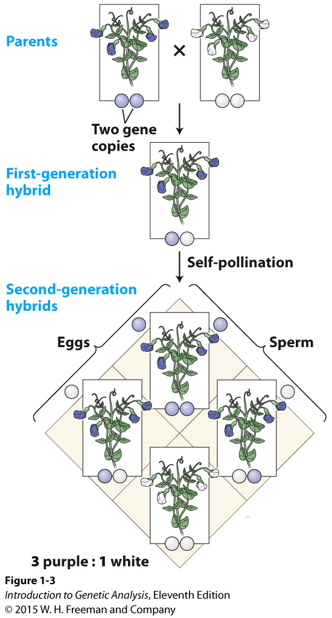

**Answer**: Let’s assign genotypes for each of these hypothetical parents. First, we assign a genotype of AA to the purple plant, and aa to the white plant. If a pure-breeding (homozygous) purple plant and a pure-breeding (homozygous) white plant mated, we would observe the following:

$$\begin{aligned}
AA \times aa \rightarrow Aa ~
\end{aligned}$$

Thus, all hybrid plants have a genotype of Aa. If we cross this to a pure-breeding white-flowered plant (aa), we observe the following:

|  | a | a |
| --- | --- | --- |
| A | Aa | Aa |
| a | aa | aa |

Like all single-locus crosses between a homozygote and heterozygote (with complete dominance), we observe a 1:1 phenotypic and genotypic ratio.

4. Figure 1-7 shows a simplified pathway for arginine synthesis in Neurospora. Suppose you have a special strain of Neurospora that makes citrulline but not arginine. Which gene(s) are likely mutant or missing in your special strain? You have a second strain of Neurospora that makes neither citrulline nor arginine but does make ornithine. Which gene(s) are mutant or missing in this strain?

[figure not shown]

**Answer**: If the mutant strain is able to produce citrulline, then genes A and B must work. Gene C, the gene responsible for the transition from citrulline to arginine, must be mutated.

In the second strain, gene A must be functional since it is able to make ornithine. Gene B must be missing or mutant since it is unable to make citrulline. However, gene C may or may not be missing or mutantated. Enzyme C converts citrulline into arginine (they are in the same sequential pathway), and enzyme C is dependent on the availability of citrulline for its function.

5. Consider Figure 1-8a.
   1. What do the small blue spheres represent?
   2. What do the brown slabs represent?
   3. Do you agree with the analogy that DNA is structured like a ladder?

[figure not shown]

**Answer**:

1. The blue ribbon represents sugar phosphate backbone (deoxyribose and a phosphate group), while the blue spheres signify atoms
2. Brown slabs show complementary bases (A, T, G, and C)
3. Yes, it is a helical structure
6. In Figure 1-8b, can you tell if the number of hydrogen bonds between adenine and thymine is the same as that between cytosine and guanine? Do you think that a DNA molecule with a high content of A + T would be more stable than one with a high content of G + C?

[figure not shown]

**Answer:** There are two hydrogen bonds between adenine and thymine and three between guanine and cytosine. Because A-T has only two hydrogen bonds it will be less stable than a molecule with a high content of G-C (three hydrogen bonds).

10. Below is the sequence of a single strand of a short DNA molecule. On a piece of paper, rewrite this sequence and then write the sequence of the complementary strand below it.

GTTCGCGGCCGCGAAC

Comparing the top and bottom strands, what do you notice about the relationship between them?

**Answer:**

GTTCGCGGCCGCGAAC

CAAGCGCCGGCGCTTG

They are palindromes — the same forwards and backwards.

11. Mendel studied a tall variety of pea plants with stems that are 20 cm long and a dwarf variety with stems that are only 12 cm long.
    1. Under blending theory, how long would you expect the stems of first and second hybrids to be?
    2. Under Mendelian rules, what would you expect to observe in the second-generation hybrids if all the first-generation hybrids were tall?

**Answer**:

1. Blending theory suggests that offspring would exhibit traits in between both parents, i.e., the average. In this case, offspring would be 16cm tall.
2. If all F1 hybrids were tall, this suggests that tall is dominant to short and all offspring are heterozygous. Thus, upon mating F1 hybrids, you would expect a 3:1 ratio of tall to short.
12. If a DNA double helix that is 100 base pairs in length has 32 adenines, how many cytosines, guanines, and thymines must it have?

**Answer:**

A = T and G = C. Therefore, 32 adenines means there are also 32 thymines, for a total of 64 bases. This means the remainder (100 - 64 = 36) are guanines and cytosines. Split 36 in two because the number of Gs and Cs are equal, and you get 18 guanine and 18 cytosine.